# Sesion 5

Mariana Vélez

2022-05-02

## Análisis multivariados

A veces hay muchas variables en un sistema y necesitamos responder preguntas como: ¿Cuáles son las variables más importantes en un set de datos? ¿Qué variables son discriminantes? ¿Qué tan parecidas son las muestras entre sí? Y para eso usamos técnicas multivariadas como análisis de ordenación, análisis de clúster o análisis de discriminantes.

## Análisis de Componentes Principales (PCA)

Principal Component Analysis (PCA) es un método estadístico que permite simplificar la complejidad de espacios muestrales con muchas dimensiones a la vez que conserva su información. El método de PCA permite por lo tanto “condensar” la información aportada por múltiples variables en solo unas pocas componentes. Una de las aplicaciones de PCA es la reducción de dimensionalidad (variables), perdiendo la menor cantidad de información (varianza) posible: cuando contamos con un gran número de variables cuantitativas posiblemente correlacionadas (indicativo de existencia de información redundante), PCA permite reducirlas a un número menor de variables transformadas (componentes principales) que expliquen gran parte de la variabilidad en los datos. Cada dimensión o componente principal generada por PCA será una combinación lineal de las variables originales, y serán además independientes o no correlacionadas entre sí

El PCA permite ver como se relacionan las variables entre sí a través de la correlación, permite ver cuanto porcentaje de la variación está relacionado con qué variables y como se ubican las muestras entre todo ese gradiente de diferentes combinaciones de las variables. En R, el paquete ade4 trae funciones para hacer PCA

```r
library(ade4)
bats<-read.delim("Murcis.txt")
bats<-bats[,c(1,10,13:18)]
bats<-na.omit(bats)
pca<-dudi.pca(bats[,3:8],center = TRUE,scale = TRUE,scannf = FALSE)
summary(pca)
```

```
## Class: pca dudi
## Call: dudi.pca(df = bats[, 3:8], center = TRUE, scale = TRUE, scannf = FALSE)
##
## Total inertia: 6
##
## Eigenvalues:
##     Ax1     Ax2     Ax3     Ax4     Ax5
##  3.6356  1.2080  0.4114  0.3746  0.2292
##
## Projected inertia (%):
##     Ax1     Ax2     Ax3     Ax4     Ax5
##  60.594  20.133   6.857   6.243   3.819
##
## Cumulative projected inertia (%):
##     Ax1   Ax1:2   Ax1:3   Ax1:4   Ax1:5
##   60.59   80.73   87.58   93.83   97.65
##
## (Only 5 dimensions (out of 6) are shown)
```

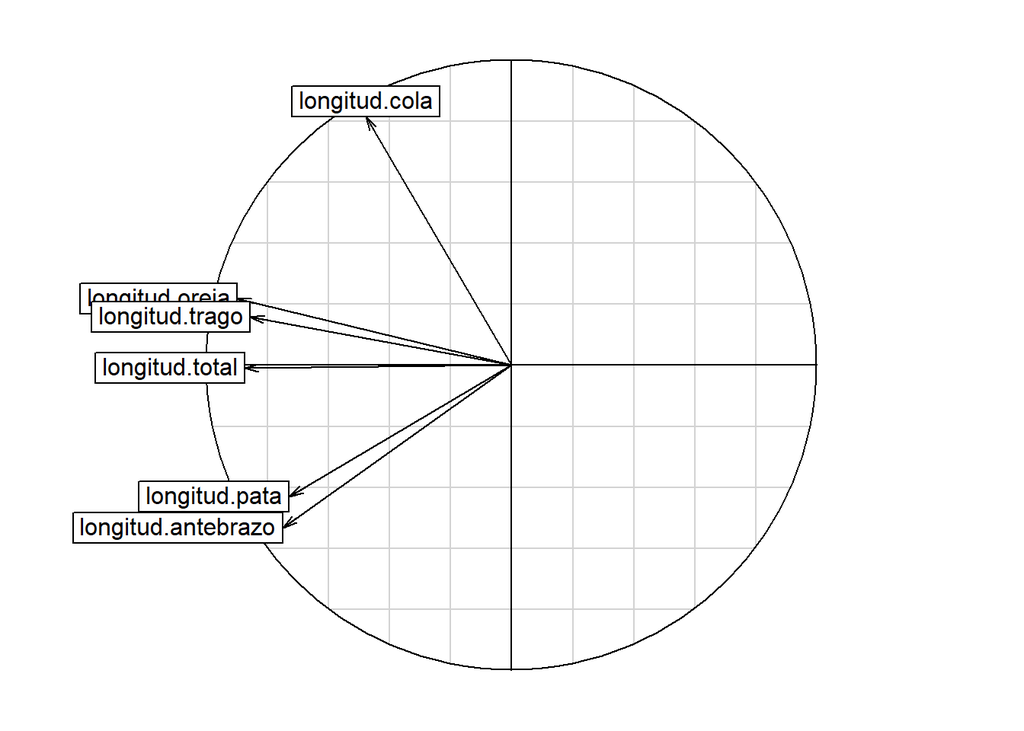

```r
s.corcircle(pca$co)
```

```r
pca$co
```

```
##                         Comp1        Comp2
## longitud.total     -0.8747727 -0.009944179
## longitud.cola      -0.4783911  0.815703229
## longitud.pata      -0.7293718 -0.430631833
## longitud.oreja     -0.8998136  0.218038754
## longitud.trago     -0.8578624  0.159313388
## longitud.antebrazo -0.7509761 -0.533037893
```

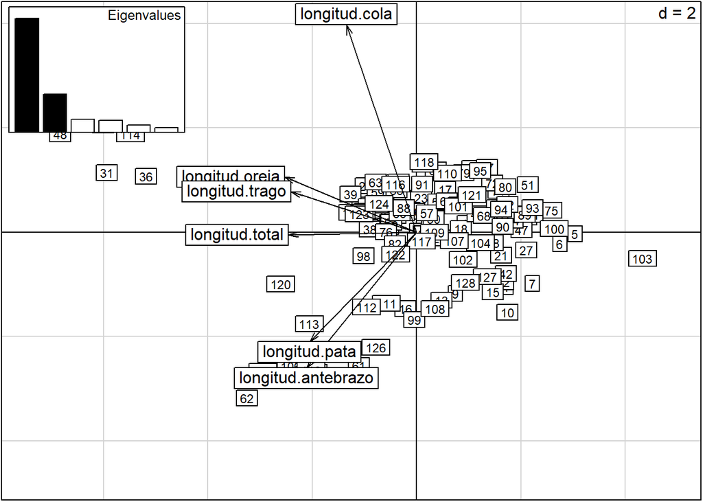

```r
biplot(pca)
```

Center es un argumento de tipo lógico o numérico que indica cómo se está centrando la variable, si center es TRUE se está centrando a partir de la media, si center es FALSE no se está centrando y si center es numérico es porque se está dando un vector con el número de columnas del data frame y da el descentramiento

Scale es un argumento lógico que indica si las columnas están siendo puestas en la misma escala de manera que sean comparables entre sí.

## Análisis de Correspondencias Canónicas

El Análisis de Correspondencia Canónica (CCA) sirve para analizar una tabla de contingencia (habitualmente con ubicaciones como filas y especies en columnas) teniendo en cuenta la información proporcionada por un conjunto de variables explicativas contenidas en una segunda tabla y medidas en las mismas ubicaciones. El Análisis de Correspondencia Canónica (CCA) permite relacionar la abundancia de especies con las variables del entorno.

```r
library(vegan)
```

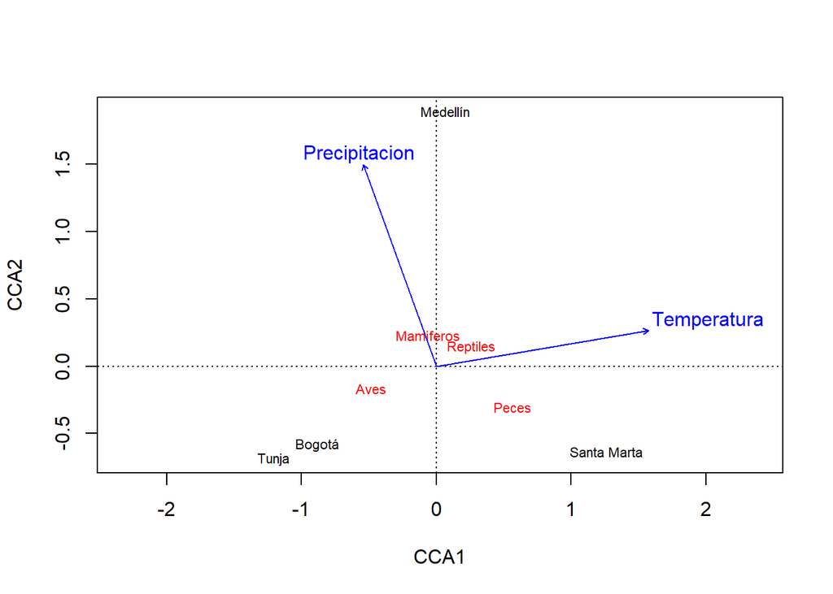

```r
ciudades<-c("Medellín","Bogotá","Santa Marta","Tunja")
mamiferos<-c(45,23,30,21)
reptiles<-c(32,10,45,19)
peces<-c(9,10,45,7)
aves<-c(20,34,21,50)
temp<-c(25,17,30,18)
precip<-c(2958,1091,977,2026)


datos<-matrix(data = c(mamiferos,reptiles,peces,aves,temp,precip),nrow = 4,ncol = 6)
row.names(datos)<-ciudades
colnames(datos)<-c("Mamiferos","Reptiles","Peces","Aves","Temperatura","Precipitacion")

cca<-cca(datos[,1:4],datos[,5:6])
plot(cca)
```